# Spatial Regression

Daniel Redwine

# Introduction

This document contains examples of spatial regression analyses using socioeconomic predictors for the response of percentage of children living below the poverty line in Alabama counties.

The dataset used in these examples can be obtained from github [here](https://raw.githubusercontent.com/chrismgentry/Spatial-Regression/master/Data/childpov18_southfull.csv).

# Analyses

## *Linear Regression*

```
##
## Call:
## lm(formula = equation, data = al_pov)
##
## Residuals:
##      Min       1Q   Median       3Q      Max
## -12.0557  -3.1371  -0.7005   3.0650  12.1511
##
## Coefficients:
##                  Estimate Std. Error t value  Pr(>|t|)
## (Intercept)     -113.5396    40.3705  -2.812   0.00701 **
## rural              3.3447     2.7547   1.214   0.23038
## urban             -3.2229     2.0859  -1.545   0.12863
## lnmanufacturing   -1.0017     4.0259  -0.249   0.80453
## lnag              -0.3857     1.4348  -0.269   0.78917
## lnretail           3.7767     5.5630   0.679   0.50033
## lnhealthss        14.3452     6.4672   2.218   0.03112 *
## lnconstruction     5.5326     3.1442   1.760   0.08459 .
## lnlesshs           8.1630     6.9808   1.169   0.24780
## lnunemployment    26.7752     6.2516   4.283 0.0000836 ***
## lnsinglemom       14.9424     5.5171   2.708   0.00923 **
## lnblack            0.1851     1.3324   0.139   0.89008
## lnhispanic         4.3926     1.5490   2.836   0.00658 **
## lnuninsured       -9.8133    11.1783  -0.878   0.38420
## lnincome_ratio   -16.6102     9.9559  -1.668   0.10149
## lnteenbirth        3.7111     4.9205   0.754   0.45425
## lnunmarried        0.6630     2.2003   0.301   0.76443
## ---
## Signif. codes:  0 '***' 0.001 '**' 0.01 '*' 0.05 '.' 0.1 ' ' 1
##
## Residual standard error: 5.854 on 50 degrees of freedom
## Multiple R-squared:  0.7597, Adjusted R-squared:  0.6828
## F-statistic: 9.881 on 16 and 50 DF,  p-value: 1.769e-10
```

Healthcare, unemployment, single mothers, and hispanic households are statistically significant predictors for the Ordinary Least Squares (OLS) Regression.

R-squared=0.6828 and p<0.0001

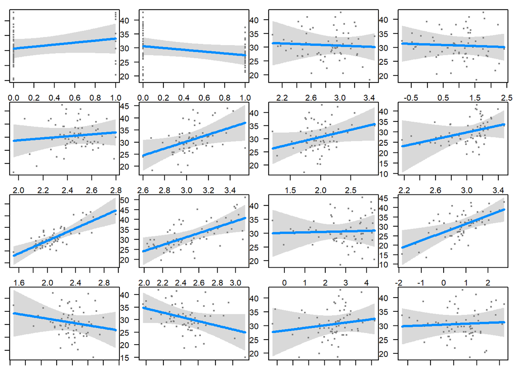

**Figure 1.** Regression plots for all predictors of child poverty.

## *Moran’s Correlation Test*

```
##
##  Global Moran I for regression residuals
##
## data:
## model: lm(formula = equation, data = al_pov)
## weights: cont.neighb
##
## Moran I statistic standard deviate = -0.92502, p-value = 0.8225
## alternative hypothesis: greater
## sample estimates:
## Observed Moran I      Expectation         Variance
##     -0.088983522     -0.020712394      0.005447183
```

Our p-value is not significant (p > 0.05).

We reject the alternative hypothesis that there is spatial dependency in our dataset.

Therefore, the OLS Regression is the best analysis for this dataset.

## *LaGrange Multiplier Test*

```
##
##  Lagrange multiplier diagnostics for spatial dependence
##
## data:
## model: lm(formula = equation, data = al_pov)
## weights: cont.neighb
##
## LMerr = 1.2857, df = 1, p-value = 0.2568
##
##
##  Lagrange multiplier diagnostics for spatial dependence
##
## data:
## model: lm(formula = equation, data = al_pov)
## weights: cont.neighb
##
## LMlag = 3.0018, df = 1, p-value = 0.08317
##
##
##  Lagrange multiplier diagnostics for spatial dependence
##
## data:
## model: lm(formula = equation, data = al_pov)
## weights: cont.neighb
##
## RLMerr = 0.011115, df = 1, p-value = 0.916
##
##
##  Lagrange multiplier diagnostics for spatial dependence
##
## data:
## model: lm(formula = equation, data = al_pov)
## weights: cont.neighb
##
## RLMlag = 1.7273, df = 1, p-value = 0.1888
##
##
##  Lagrange multiplier diagnostics for spatial dependence
##
## data:
## model: lm(formula = equation, data = al_pov)
## weights: cont.neighb
##
## SARMA = 3.0129, df = 2, p-value = 0.2217
```

Our p-value is not significant (p > 0.05) for either the Spatially Lagged X Model or the Spatial Error Model.

Therefore, the OLS Regression is a better fit for the data.

However, we will run those models below for demonstration purposes.

## *Spatially Lagged X Model*

```
##
## Call:
## lm(formula = formula(paste("y ~ ", paste(colnames(x)[-1], collapse = "+"))),
##     data = as.data.frame(x), weights = weights)
##
## Residuals:
##     Min      1Q  Median      3Q     Max
## -8.2673 -2.8738 -0.3905  2.2418 11.3565
##
## Coefficients:
##                       Estimate Std. Error t value Pr(>|t|)
## (Intercept)         -160.94520  132.69998  -1.213  0.23355
## rural                  3.72532    2.73277   1.363  0.18178
## urban                 -3.07189    2.47452  -1.241  0.22295
## lnmanufacturing       -5.02631    5.82896  -0.862  0.39456
## lnag                  -1.38144    1.60416  -0.861  0.39518
## lnretail               6.93548    6.32091   1.097  0.28025
## lnhealthss            21.54070    7.87317   2.736  0.00981 **
## lnconstruction         7.39438    3.88115   1.905  0.06524 .
## lnlesshs              17.69165   10.18944   1.736  0.09157 .
## lnunemployment        27.19074    7.20894   3.772  0.00062 ***
## lnsinglemom            4.34669    8.36535   0.520  0.60670
## lnblack               -0.08093    1.45267  -0.056  0.95590
## lnhispanic             4.69457    1.70884   2.747  0.00954 **
## lnuninsured          -19.92636   12.41179  -1.605  0.11765
## lnincome_ratio        -8.11715   15.70628  -0.517  0.60864
## lnteenbirth            1.73086    5.95686   0.291  0.77315
## lnunmarried            5.49609    2.93855   1.870  0.07007 .
## lag.rural              4.58983    7.24152   0.634  0.53044
## lag.urban              8.85268    5.53445   1.600  0.11895
## lag.lnmanufacturing   10.11951   14.87522   0.680  0.50093
## lag.lnag               4.83083    3.79948   1.271  0.21220
## lag.lnretail          20.28744   13.93565   1.456  0.15462
## lag.lnhealthss        29.12457   23.04766   1.264  0.21495
## lag.lnconstruction    -9.61048   11.10911  -0.865  0.39305
## lag.lnlesshs          13.74468   27.01304   0.509  0.61417
## lag.lnunemployment   -16.81149   15.75200  -1.067  0.29337
## lag.lnsinglemom      -46.05382   23.42468  -1.966  0.05750 .
## lag.lnblack            4.20631    3.43747   1.224  0.22949
## lag.lnhispanic         0.80422    3.59439   0.224  0.82430
## lag.lnuninsured      -36.61463   33.41830  -1.096  0.28093
## lag.lnincome_ratio    32.86674   39.00319   0.843  0.40530
## lag.lnteenbirth      -11.41014   18.69709  -0.610  0.54575
## lag.lnunmarried       16.64566    7.45831   2.232  0.03232 *
## ---
## Signif. codes:  0 '***' 0.001 '**' 0.01 '*' 0.05 '.' 0.1 ' ' 1
##
## Residual standard error: 5.463 on 34 degrees of freedom
## Multiple R-squared:  0.8577, Adjusted R-squared:  0.7238
## F-statistic: 6.405 on 32 and 34 DF,  p-value: 0.0000002628
```

Healthcare, unemployment, hispanic households, and neighboring region unmarried households are statistically significant for the Spatially Lagged X Model.

R-squared=0.7238 and p<0.0001

```
##                       Direct   Indirect      Total
## rural           0.1728193465 0.52619713 0.29622599
## urban           0.2144543627 0.10969632 0.35899137
## lnmanufacturing 0.3885218443 0.49631853 0.78582511
## lnag            0.3891476328 0.20357022 0.39167587
## lnretail        0.2725417737 0.14544947 0.09711271
## lnhealthss      0.0062197785 0.20634946 0.06419060
## lnconstruction  0.0567536785 0.38698455 0.86852818
## lnlesshs        0.0825156723 0.61088099 0.35640614
## lnunemployment  0.0001620704 0.28585395 0.53461292
## lnsinglemom     0.6033376718 0.04929423 0.14936317
## lnblack         0.9555698362 0.22107927 0.28608239
## lnhispanic      0.0060102044 0.82295791 0.15487651
## lnuninsured     0.1083973313 0.27323364 0.13848815
## lnincome_ratio  0.6052894748 0.39941420 0.62347640
## lnteenbirth     0.7713830719 0.54168765 0.66296402
## lnunmarried     0.0614361935 0.02562637 0.01762846
```

## *Spatial Lag Model*

```
##
## Call:
## spatialreg::lagsarlm(formula = equation, data = al_pov, listw = cont.neighb)
##
## Residuals:
##       Min        1Q    Median        3Q       Max
## -11.74054  -3.33504  -0.81097   3.07152  11.24607
##
## Type: lag
## Coefficients: (asymptotic standard errors)
##                   Estimate Std. Error z value      Pr(>|z|)
## (Intercept)     -106.44513   34.27467 -3.1056     0.0018986
## rural              3.33397    2.31882  1.4378     0.1504952
## urban             -3.17151    1.76160 -1.8004     0.0718038
## lnmanufacturing   -0.74464    3.38438 -0.2200     0.8258534
## lnag              -0.48794    1.20771 -0.4040     0.6861960
## lnretail           4.38155    4.68165  0.9359     0.3493258
## lnhealthss        15.58606    5.44940  2.8601     0.0042345
## lnconstruction     5.66643    2.65793  2.1319     0.0330156
## lnlesshs           7.35443    5.90318  1.2458     0.2128223
## lnunemployment    29.11634    5.37140  5.4206 0.00000005939
## lnsinglemom       12.74741    4.75527  2.6807     0.0073470
## lnblack            0.18428    1.12016  0.1645     0.8693302
## lnhispanic         4.57330    1.30366  3.5081     0.0004514
## lnuninsured      -12.43943    9.46265 -1.3146     0.1886503
## lnincome_ratio   -16.42511    8.37009 -1.9624     0.0497208
## lnteenbirth        3.84237    4.14900  0.9261     0.3543962
## lnunmarried        1.52206    1.89249  0.8043     0.4212459
##
## Rho: -0.22551, LR test value: 2.9969, p-value: 0.083422
## Asymptotic standard error: 0.13453
##     z-value: -1.6763, p-value: 0.093682
## Wald statistic: 2.8099, p-value: 0.093682
##
## Log likelihood: -202.1679 for lag model
## ML residual variance (sigma squared): 24.22, (sigma: 4.9214)
## Nagelkerke pseudo-R-squared: 0.77023
## Number of observations: 67
## Number of parameters estimated: 19
## AIC: 442.34, (AIC for lm: 443.33)
## LM test for residual autocorrelation
## test value: 0.034171, p-value: 0.85334
```

Healthcare, construction, single mothers, hispanic households, and income ratio are significant predictors for the Spatial Lag Model.

R-squared=0.7702 and p>0.05

```
##                          Direct   Indirect         Total
## rural           0.1691700382788 0.29660257 0.18356227437
## urban           0.1044138595263 0.25621229 0.09407195094
## lnmanufacturing 0.8575757247210 0.84023525 0.87103647822
## lnag            0.7112641229531 0.74018217 0.71442871224
## lnretail        0.3799285810984 0.50744589 0.38326264454
## lnhealthss      0.0007938387262 0.11586206 0.00119729597
## lnconstruction  0.0282692389467 0.16436719 0.03212297205
## lnlesshs        0.2238501862828 0.38859090 0.23079604021
## lnunemployment  0.0000001352106 0.07289193 0.00000327969
## lnsinglemom     0.0032314626012 0.09940608 0.00997221019
## lnblack         0.8861863679737 0.85581790 0.89890847664
## lnhispanic      0.0001176359813 0.09719148 0.00047031257
## lnuninsured     0.1996749217573 0.33593708 0.20792555679
## lnincome_ratio  0.0495918426805 0.19467967 0.05585195215
## lnteenbirth     0.2876772058324 0.39160155 0.28657823704
## lnunmarried     0.3876244296588 0.44917401 0.38930669924
```

Healthcare, construction, unempployment, single moms, hispanic households, and income ratio have significant impacts.

## *Spatial Error Model*

```
##
## Call:
## spatialreg::errorsarlm(formula = equation, data = al_pov, listw = cont.neighb)
##
## Residuals:
##       Min        1Q    Median        3Q       Max
## -10.60804  -2.74638  -0.53251   2.80265  10.49762
##
## Type: error
## Coefficients: (asymptotic standard errors)
##                    Estimate  Std. Error z value  Pr(>|z|)
## (Intercept)     -109.113190   32.076990 -3.4016 0.0006699
## rural              4.641296    2.143791  2.1650 0.0303881
## urban             -1.227391    1.490279 -0.8236 0.4101680
## lnmanufacturing    0.019136    3.446265  0.0056 0.9955697
## lnag              -0.180245    1.009002 -0.1786 0.8582231
## lnretail           6.116851    4.214233  1.4515 0.1466478
## lnhealthss        18.538035    5.466239  3.3914 0.0006954
## lnconstruction     2.695138    2.653489  1.0157 0.3097741
## lnlesshs          11.603412    6.018648  1.9279 0.0538663
## lnunemployment    28.650772    4.277874  6.6974 2.121e-11
## lnsinglemom       11.022022    4.787854  2.3021 0.0213307
## lnblack            0.258885    0.971858  0.2664 0.7899452
## lnhispanic         5.049973    1.112258  4.5403 5.618e-06
## lnuninsured      -18.553480    8.993837 -2.0629 0.0391211
## lnincome_ratio   -12.885262    8.798902 -1.4644 0.1430800
## lnteenbirth        0.199109    4.213335  0.0473 0.9623085
## lnunmarried        2.151303    1.857474  1.1582 0.2467875
##
## Lambda: -0.81439, LR test value: 4.7775, p-value: 0.028835
## Asymptotic standard error: 0.1872
##     z-value: -4.3504, p-value: 0.000013591
## Wald statistic: 18.926, p-value: 0.000013591
##
## Log likelihood: -201.2776 for error model
## ML residual variance (sigma squared): 21.011, (sigma: 4.5838)
## Nagelkerke pseudo-R-squared: 0.77626
## Number of observations: 67
## Number of parameters estimated: 19
## AIC: NA (not available for weighted model), (AIC for lm: 443.33)
```

Rural, healthcare, unemployment, single mothers, hispanic households, and uninsured households were significant predictors of child poverty in the Spatial Error Model.

R-sqared=0.7763 and p<0.05

## *Hausman Test*

```
##
##  Spatial Hausman test (asymptotic)
##
## data:  NULL
## Hausman test = 29.953, df = 17, p-value = 0.02669
```

We reject the null hypothesis that the estimation method yields coefficients acceptable for a standard error model due to p<0.05.

A Standard Error Model may not be appropriate for this dataset as indicated above.

## *Nested Spatial Durbin Models*

```
##
## Call:
## spatialreg::errorsarlm(formula = equation, data = al_pov, listw = cont.neighb,
##     etype = "emixed")
##
## Residuals:
##       Min        1Q    Median        3Q       Max
## -7.000840 -2.143267 -0.091544  2.017744  7.871576
##
## Type: error
## Coefficients: (asymptotic standard errors)
##                       Estimate Std. Error z value     Pr(>|z|)
## (Intercept)         -274.67030   72.87052 -3.7693    0.0001637
## rural                  2.94038    1.86546  1.5762    0.1149738
## urban                 -3.33917    1.76305 -1.8940    0.0582282
## lnmanufacturing       -8.03366    3.63024 -2.2130    0.0268988
## lnag                  -1.58752    1.14287 -1.3891    0.1648128
## lnretail               3.34699    4.27094  0.7837    0.4332356
## lnhealthss            21.44500    4.76721  4.4984 0.0000068455
## lnconstruction         7.96614    2.46110  3.2368    0.0012087
## lnlesshs              22.26224    6.22077  3.5787    0.0003453
## lnunemployment        26.03239    5.19875  5.0074 0.0000005516
## lnsinglemom            3.04635    4.99195  0.6103    0.5416937
## lnblack               -0.10468    1.02180 -0.1024    0.9184035
## lnhispanic             4.80507    1.15524  4.1594 0.0000319136
## lnuninsured          -23.61557    8.06089 -2.9296    0.0033935
## lnincome_ratio        -4.76255    9.74313 -0.4888    0.6249753
## lnteenbirth           -0.32346    3.73753 -0.0865    0.9310348
## lnunmarried            5.52182    1.79907  3.0693    0.0021458
## lag.rural              6.54710    4.23739  1.5451    0.1223269
## lag.urban              8.67961    3.26920  2.6550    0.0079316
## lag.lnmanufacturing   10.46138    9.54223  1.0963    0.2729367
## lag.lnag               1.88523    2.29109  0.8229    0.4105929
## lag.lnretail          32.15534    9.19512  3.4970    0.0004705
## lag.lnhealthss        41.06211   14.51409  2.8291    0.0046676
## lag.lnconstruction    -4.88717    6.55536 -0.7455    0.4559556
## lag.lnlesshs          30.62619   17.38387  1.7618    0.0781100
## lag.lnunemployment   -20.42952   10.39556 -1.9652    0.0493893
## lag.lnsinglemom      -46.90029   15.06296 -3.1136    0.0018481
## lag.lnblack            4.81346    2.15463  2.2340    0.0254828
## lag.lnhispanic         2.47139    2.09735  1.1783    0.2386616
## lag.lnuninsured      -47.91671   20.18125 -2.3743    0.0175814
## lag.lnincome_ratio    60.41350   24.20447  2.4960    0.0125615
## lag.lnteenbirth       -8.78161   12.75217 -0.6886    0.4910518
## lag.lnunmarried       15.12904    4.20459  3.5982    0.0003204
##
## Lambda: -0.98238, LR test value: 9.4383, p-value: 0.0021249
## Asymptotic standard error: 0.17313
##     z-value: -5.6741, p-value: 0.000000013942
## Wald statistic: 32.195, p-value: 0.000000013942
##
## Log likelihood: -181.3931 for error model
## ML residual variance (sigma squared): 10.929, (sigma: 3.3059)
## Nagelkerke pseudo-R-squared: 0.87641
## Number of observations: 67
## Number of parameters estimated: 35
## AIC: NA (not available for weighted model), (AIC for lm: 440.22)
```

Results for the Spatial Durbin Error Model.

```
##                          Direct     Indirect         Total
## rural           0.1149737987734 0.1223268543 0.01155030203
## urban           0.0582282423912 0.0079316107 0.09644299644
## lnmanufacturing 0.0268988102488 0.2729367176 0.81547946810
## lnag            0.1648128296007 0.4105928705 0.88439560539
## lnretail        0.4332356399681 0.0004705188 0.00003657289
## lnhealthss      0.0000068454637 0.0046676029 0.00003537401
## lnconstruction  0.0012086833821 0.4559555737 0.65529852261
## lnlesshs        0.0003453124591 0.0781100378 0.00804370016
## lnunemployment  0.0000005515995 0.0493892525 0.52249495534
## lnsinglemom     0.5416937086476 0.0018480904 0.00961756983
## lnblack         0.9184034792385 0.0254827675 0.01904874775
## lnhispanic      0.0000319136108 0.2386615841 0.00006623845
## lnuninsured     0.0033934637473 0.0175814035 0.00033974918
## lnincome_ratio  0.6249753350306 0.0125615265 0.05441593666
## lnteenbirth     0.9310348319729 0.4910517591 0.50781696323
## lnunmarried     0.0021458313683 0.0003204051 0.00001589066
```

Retail, healthcare, less than high school education, single moms, black households, hispanic households, uninsured households, and unmarried households have significant impacts.

```
##
##  Likelihood ratio for spatial linear models
##
## data:
## Likelihood ratio = 39.769, df = 16, p-value = 0.0008413
## sample estimates:
##       Log likelihood of sd.err Log likelihood of sp.err.model
##                      -181.3931                      -201.2776
```

With p<0.05 we reject the null hypothesis, meaning that we should not restrict the model to a spatial error model.

## *Distance Lag Model*

```
##
## Call:
## spatialreg::lagsarlm(formula = equation, data = al_pov, listw = all.dist.neighb.k1)
##
## Residuals:
##       Min        1Q    Median        3Q       Max
## -12.12907  -2.84198  -0.68736   3.21810  11.71131
##
## Type: lag
## Coefficients: (asymptotic standard errors)
##                    Estimate  Std. Error z value     Pr(>|z|)
## (Intercept)     -111.067955   34.520819 -3.2174     0.001293
## rural              3.501351    2.350709  1.4895     0.136359
## urban             -3.055272    1.780709 -1.7158     0.086206
## lnmanufacturing   -0.827701    3.438889 -0.2407     0.809796
## lnag              -0.378545    1.224120 -0.3092     0.757140
## lnretail           4.004627    4.747339  0.8436     0.398920
## lnhealthss        15.426971    5.556643  2.7763     0.005498
## lnconstruction     5.437294    2.690647  2.0208     0.043299
## lnlesshs           8.907720    5.962373  1.4940     0.135178
## lnunemployment    27.626652    5.360089  5.1541 0.0000002548
## lnsinglemom       13.974122    4.763419  2.9336     0.003350
## lnblack            0.086976    1.145259  0.0759     0.939463
## lnhispanic         4.596336    1.323105  3.4739     0.000513
## lnuninsured      -11.632543    9.610920 -1.2103     0.226146
## lnincome_ratio   -16.374469    8.503296 -1.9257     0.054147
## lnteenbirth        3.357993    4.198106  0.7999     0.423779
## lnunmarried        1.053064    1.906082  0.5525     0.580622
##
## Rho: -0.11548, LR test value: 1.3745, p-value: 0.24105
## Asymptotic standard error: 0.10317
##     z-value: -1.1193, p-value: 0.26301
## Wald statistic: 1.2529, p-value: 0.26301
##
## Log likelihood: -202.9791 for lag model
## ML residual variance (sigma squared): 24.947, (sigma: 4.9947)
## Nagelkerke pseudo-R-squared: 0.7646
## Number of observations: 67
## Number of parameters estimated: 19
## AIC: 443.96, (AIC for lm: 443.33)
## LM test for residual autocorrelation
## test value: 0.34572, p-value: 0.55655
```

Distance Lag Model for K=1.

## *Distance Error Model*

```
##
## Call:
## spatialreg::errorsarlm(formula = equation, data = al_pov, listw = all.dist.neighb.k1)
##
## Residuals:
##       Min        1Q    Median        3Q       Max
## -12.16984  -2.94494  -0.75243   3.06584  11.91195
##
## Type: error
## Coefficients: (asymptotic standard errors)
##                   Estimate Std. Error z value    Pr(>|z|)
## (Intercept)     -112.45326   34.88002 -3.2240   0.0012641
## rural              3.63455    2.35824  1.5412   0.1232658
## urban             -3.03532    1.76806 -1.7168   0.0860245
## lnmanufacturing   -1.01893    3.50074 -0.2911   0.7710040
## lnag              -0.36575    1.21949 -0.2999   0.7642360
## lnretail           4.23577    4.81594  0.8795   0.3791130
## lnhealthss        14.75597    5.61305  2.6289   0.0085670
## lnconstruction     4.94225    2.72009  1.8169   0.0692253
## lnlesshs           8.85664    6.00042  1.4760   0.1399433
## lnunemployment    26.88202    5.27236  5.0987 0.000000342
## lnsinglemom       14.67737    4.79035  3.0639   0.0021844
## lnblack            0.28130    1.13995  0.2468   0.8050870
## lnhispanic         4.57084    1.32864  3.4402   0.0005812
## lnuninsured      -10.38101    9.54713 -1.0873   0.2768848
## lnincome_ratio   -16.96559    8.48795 -1.9988   0.0456315
## lnteenbirth        3.07880    4.30982  0.7144   0.4749991
## lnunmarried        0.71437    1.91913  0.3722   0.7097176
##
## Lambda: -0.10536, LR test value: 0.29156, p-value: 0.58922
## Asymptotic standard error: 0.14605
##     z-value: -0.72137, p-value: 0.47068
## Wald statistic: 0.52038, p-value: 0.47068
##
## Log likelihood: -203.5206 for error model
## ML residual variance (sigma squared): 25.372, (sigma: 5.0371)
## Nagelkerke pseudo-R-squared: 0.76076
## Number of observations: 67
## Number of parameters estimated: 19
## AIC: NA (not available for weighted model), (AIC for lm: 443.33)
```

Distance Error Model for K=1.

# Results

```
##
## Call:
## lm(formula = equation, data = al_pov)
##
## Residuals:
##      Min       1Q   Median       3Q      Max
## -12.0557  -3.1371  -0.7005   3.0650  12.1511
##
## Coefficients:
##                  Estimate Std. Error t value  Pr(>|t|)
## (Intercept)     -113.5396    40.3705  -2.812   0.00701 **
## rural              3.3447     2.7547   1.214   0.23038
## urban             -3.2229     2.0859  -1.545   0.12863
## lnmanufacturing   -1.0017     4.0259  -0.249   0.80453
## lnag              -0.3857     1.4348  -0.269   0.78917
## lnretail           3.7767     5.5630   0.679   0.50033
## lnhealthss        14.3452     6.4672   2.218   0.03112 *
## lnconstruction     5.5326     3.1442   1.760   0.08459 .
## lnlesshs           8.1630     6.9808   1.169   0.24780
## lnunemployment    26.7752     6.2516   4.283 0.0000836 ***
## lnsinglemom       14.9424     5.5171   2.708   0.00923 **
## lnblack            0.1851     1.3324   0.139   0.89008
## lnhispanic         4.3926     1.5490   2.836   0.00658 **
## lnuninsured       -9.8133    11.1783  -0.878   0.38420
## lnincome_ratio   -16.6102     9.9559  -1.668   0.10149
## lnteenbirth        3.7111     4.9205   0.754   0.45425
## lnunmarried        0.6630     2.2003   0.301   0.76443
## ---
## Signif. codes:  0 '***' 0.001 '**' 0.01 '*' 0.05 '.' 0.1 ' ' 1
##
## Residual standard error: 5.854 on 50 degrees of freedom
## Multiple R-squared:  0.7597, Adjusted R-squared:  0.6828
## F-statistic: 9.881 on 16 and 50 DF,  p-value: 1.769e-10
```

As determined in the analyses above, the OLS Regression was the best fit for the data.

Healthcare, unemployment, single mother households, and hispanic households are significant predictors of child poverty for counties in Alabama.

R-squared=0.6828 and p<0.0001

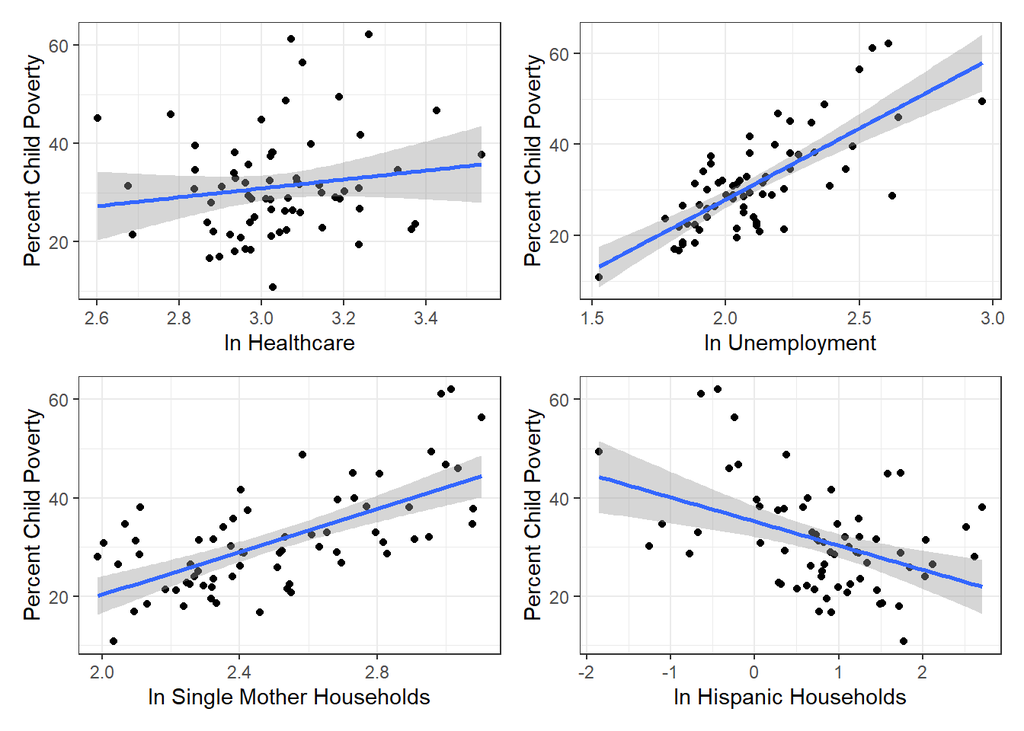

**Figure 2.** Regression plots of healthcare, unemployment, single mothers, and hispanic households for the response of child poverty

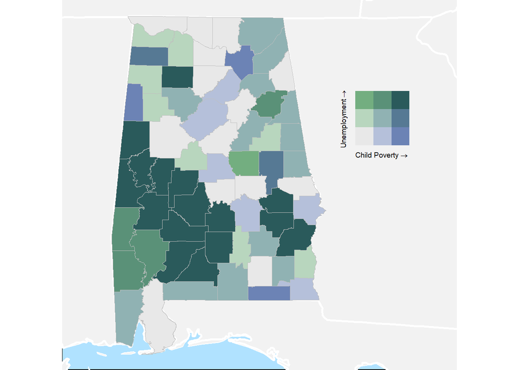

**Figure 3.** Bivarate map of child poverty and unemployment in Alabama counties.